# Avaliação Continuada - Aula 5

**Execute a célula a seguir para importar as bibliotecas de que vamos precisar e criar a variável `taxis` com nossa base de dados.**

```python
# Importando a biblioteca seaborn
import seaborn as sns
import matplotlib.pyplot as plt

# Carregando a base de dados 'taxis'
taxis = sns.load_dataset("taxis")

# Essa linha cria uma nova coluna
# Você não precisa se preocupar com ela no momento
taxis["pickup_hour"] = taxis["pickup"].dt.hour

taxis.head(2)
```

|  | pickup | dropoff | passengers | distance | fare | tip | tolls | total | color | payment | pickup_zone | dropoff_zone | pickup_borough | dropoff_borough | pickup_hour |
| --- | --- | --- | --- | --- | --- | --- | --- | --- | --- | --- | --- | --- | --- | --- | --- |
| 0 | 2019-03-23 20:21:09 | 2019-03-23 20:27:24 | 1 | 1.60 | 7.0 | 2.15 | 0.0 | 12.95 | yellow | credit card | Lenox Hill West | UN/Turtle Bay South | Manhattan | Manhattan | 20 |
| 1 | 2019-03-04 16:11:55 | 2019-03-04 16:19:00 | 1 | 0.79 | 5.0 | 0.00 | 0.0 | 9.30 | yellow | cash | Upper West Side South | Upper West Side South | Manhattan | Manhattan | 16 |

### Sobre os dados

No exercício de hoje, vamos utilizar as seguintes variáveis:

- `pickup_hour`: hora em que a viagem foi iniciada.
- `tip`: valor da gorjeta dada ao motorista.

Nosso objetivo é verificar se há algum horário melhor para um taxista que queira maximizar o valor das gorjetas que recebe.

### Exercício de hoje - Parte 1

Utilize a função `sns.lineplot()` para criar um gráfico de linha que exiba a gorjeta média a partir da hora de início da viagem, e remova também a barra de erro com o argumento `errorbar=None`.

Após escrever a linha de código de sua resposta, execute a célula para mostrar o gráfico a partir da base `taxis`.

**Importante: antes de executar o código da sua resposta, não deixe de executar a célula de código que está no início deste caderno, que importa as bibliotecas e carrega os dados.**

```python
# Escreva sua resposta abaixo
```

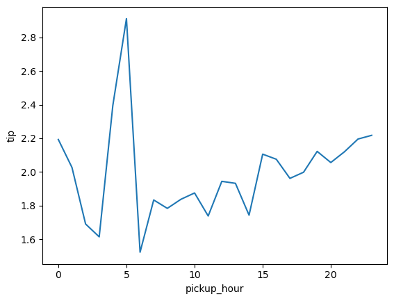

```python
# Gabarito

# Escreva sua resposta abaixo
sns.lineplot(
    x="pickup_hour",
    y="tip",
    errorbar=None,
    estimator="mean", # linha opcional
    data=taxis
)
```

### Exercício de hoje - Parte 2

Agora você produzir o mesmo gráfico, mas deve customizá-lo:

- adicione título ao gráfico,
- adicione e rótulos nos eixos, e
- aumente o tamanho das dimensões do gráfico usando a função: `plt.subplots()` (uma sugestão é usar: `figsize=(12,6)`)

```python
# Continue o código abaixo
fig, ax = plt.subplots(figsize=(_, _))
```

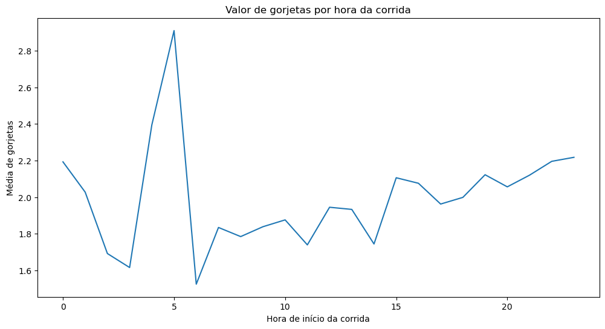

```python
# Gabarito
# O tamanho da figura poderia ser outro!
fig, ax = plt.subplots(figsize=(12, 6))

sns.lineplot(
    x="pickup_hour",
    y="tip",
    estimator="mean", # Essa linha é opcional
    errorbar=None,
    data=taxis
)

# Qualquer título e eixos são válidos como resposta!
ax.set_title("Valor de gorjetas por hora da corrida")
ax.set_xlabel("Hora de início da corrida")
ax.set_ylabel("Média de gorjetas")
```